# Fiscalia y Judicatura

2025-04-15

# 1 Fiscalia

La base de datos de Fiscalía tiene un total de 403, al utilizar la variable “d_NDD” como identificador único de cada registro se pudo constatar que existen 403 registros diferentes.

En la siguiente tabla se presentan el número de casos presentes en la base de datos por año.

## 1.1 Número de casos por año

| anio | casos |
| --- | --- |
| 2022 | 114 |
| 2023 | 117 |
| 2024 | 172 |
| Total | 403 |

Se solicitó realizar el número de casos por taxón, pero esta información no está presente en la base de datos. En la siguiente tabla se presenta el número de casos por Provincia y año.

## 1.2 Número de casos por provincia y año

| Provincia | 2022 | 2023 | 2024 | Total |
| --- | --- | --- | --- | --- |
| AZUAY | 2 | 2 | 3 | 7 |
| BOLIVAR | 0 | 2 | 3 | 5 |
| CANAR | 1 | 0 | 1 | 2 |
| CARCHI | 3 | 2 | 2 | 7 |
| COTOPAXI | 3 | 0 | 4 | 7 |
| EL ORO | 8 | 5 | 18 | 31 |
| ESMERALDAS | 3 | 5 | 6 | 14 |
| GALAPAGOS | 11 | 3 | 14 | 28 |
| GUAYAS | 16 | 31 | 35 | 82 |
| IMBABURA | 7 | 2 | 5 | 14 |
| LOJA | 5 | 2 | 4 | 11 |
| LOS RIOS | 3 | 1 | 3 | 7 |
| MANABI | 4 | 10 | 4 | 18 |
| MORONA SANTIAGO | 4 | 5 | 4 | 13 |
| NAPO | 8 | 8 | 7 | 23 |
| ORELLANA | 8 | 7 | 17 | 32 |
| PASTAZA | 2 | 6 | 5 | 13 |
| PICHINCHA | 10 | 16 | 19 | 45 |
| SANTA ELENA | 8 | 1 | 3 | 12 |
| SANTO DOMINGO DE LOS TSACHILAS | 2 | 1 | 3 | 6 |
| SUCUMBIOS | 6 | 6 | 9 | 21 |
| TUNGURAHUA | 0 | 1 | 3 | 4 |
| ZAMORA CHINCHIPE | 0 | 1 | 0 | 1 |
| Total | 114 | 117 | 172 | 403 |

## 1.3 Gráfico de calor de número de casos por provincia

[figure not shown]

Finalmente se presenta un gráfico tipo raster del número de casos por año y mes.

## 1.4 Número de casos por año y mes

[figure not shown]

# 2 Judicatura

La data proveniente de la Judicatura es un archivo excel compuesto por tres pestañas “Causas Ingresadas”, “Causas Resueltas” y “Causas Razón de ejecutoría”, utilizando la variable “IDJUICIO” se pudo verificar que los juicios presentes en la primera pestaña contenían los juicios de la pesataña 2 y 3, sin embargo, en ninguna de las pestañas el “IDJUICIO” era único, para poder vincular las tres pestañas en una sola se debieron utilizar las variables “IDJUICIO”, “PROVINCIA”, “CANTON” e “INSTANCIA”.

La base de datos resultante de Judicatura tiene un total de 244, al utilizar la variable “IDJUICIO” como identificador único de cada registro se pudo constatar que existen 203 registros diferentes.

En la siguiente tabla se presentan el número de casos presentes en la base de datos por año.

## 2.1 Número de casos por año

| anio | casos |
| --- | --- |
| 2019 | 34 |
| 2020 | 19 |
| 2021 | 31 |
| 2022 | 44 |
| 2023 | 67 |
| 2024 | 49 |
| Total | 244 |

Se solicitó realizar el número de casos por taxón, pero esta información no está presente en la base de datos. En la siguiente tabla se presenta el número de casos por Provincia y año.

## 2.2 Número de casos por provincia y año

| Provincia | 2019 | 2020 | 2021 | 2022 | 2023 | 2024 | Total |
| --- | --- | --- | --- | --- | --- | --- | --- |
| AZUAY | 1 | 0 | 0 | 0 | 4 | 0 | 5 |
| EL ORO | 2 | 0 | 4 | 1 | 3 | 3 | 13 |
| ESMERALDAS | 3 | 0 | 3 | 3 | 1 | 3 | 13 |
| GALAPAGOS | 5 | 1 | 4 | 1 | 1 | 4 | 16 |
| GUAYAS | 6 | 8 | 8 | 5 | 18 | 9 | 54 |
| IMBABURA | 1 | 2 | 0 | 2 | 0 | 1 | 6 |
| MANABI | 1 | 2 | 0 | 1 | 3 | 0 | 7 |
| ORELLANA | 4 | 2 | 1 | 4 | 4 | 4 | 19 |
| PICHINCHA | 2 | 1 | 2 | 9 | 11 | 12 | 37 |
| SANTA ELENA | 4 | 0 | 2 | 1 | 0 | 0 | 7 |
| SUCUMBIOS | 1 | 1 | 0 | 4 | 3 | 4 | 13 |
| TUNGURAHUA | 4 | 0 | 0 | 0 | 2 | 4 | 10 |
| CARCHI | 0 | 1 | 0 | 3 | 3 | 0 | 7 |
| LOJA | 0 | 1 | 1 | 2 | 1 | 0 | 5 |
| MORONA SANTIAGO | 0 | 0 | 1 | 1 | 1 | 2 | 5 |
| NAPO | 0 | 0 | 3 | 3 | 11 | 1 | 18 |
| SANTO DOMINGO DE LOS TSACHILAS | 0 | 0 | 2 | 1 | 0 | 1 | 4 |
| COTOPAXI | 0 | 0 | 0 | 2 | 0 | 1 | 3 |
| LOS RIOS | 0 | 0 | 0 | 1 | 0 | 0 | 1 |
| PASTAZA | 0 | 0 | 0 | 0 | 1 | 0 | 1 |
| Total | 34 | 19 | 31 | 44 | 67 | 49 | 244 |

## 2.3 Gráfico de calor de número de casos por provincia

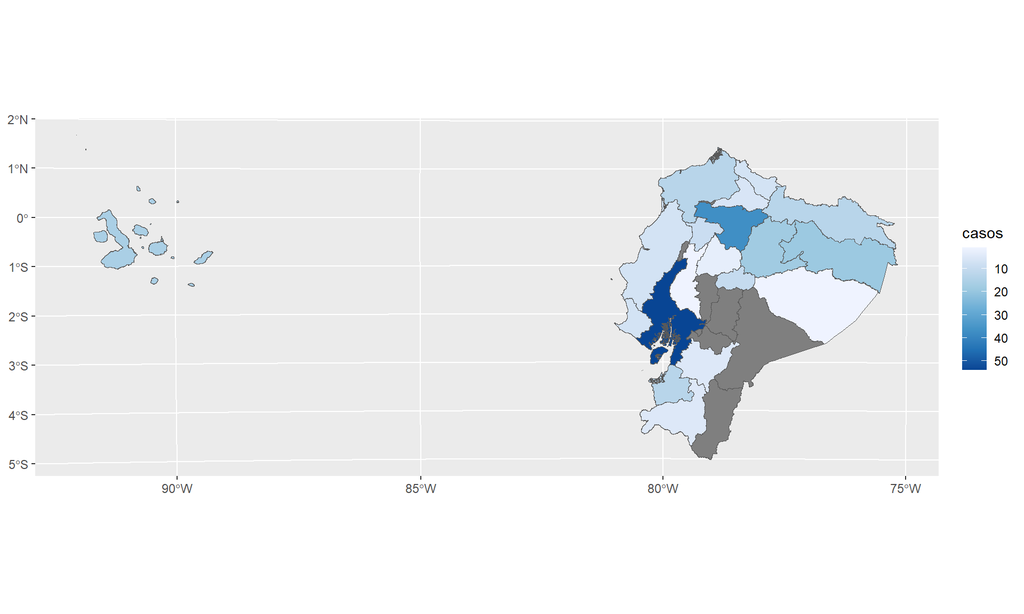

Finalmente se presenta un gráfico tipo raster del número de casos por año y mes.

## 2.4 Número de casos por año y mes

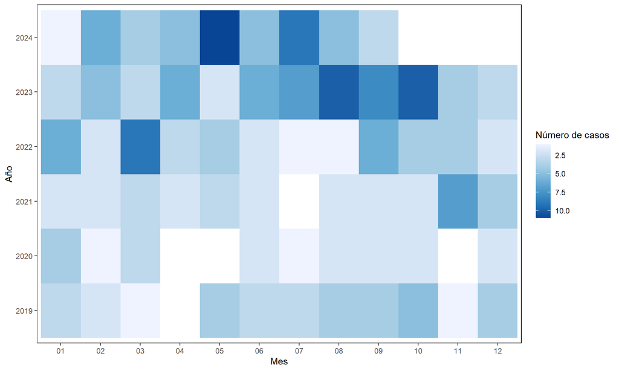